# Part II - (Prosper Loan Analysis Presentation)

## by (Chisom Nwankwo)

## Investigation Overview

> In this investigation, I wanted to look at the record of loans from Prosper loan that could be used to predict future performance. The records I am interested in for this analysis are:loan amount, borrower rate (or interest rate), current loan status, borrower income, borrower state, amongst others.

## Dataset Overview

> This data set is a record of loans from Prosper Loan in the United States. It contains 113,937 loans with 81 variables on each loan. I have already carried out preliminary cleaning and wrangling, as well as exploratory visualization on the dataset. in this report, I will be focus more on the insights i can gather from this datasets.

## Distribution of Credit Ratings

the data set has two specific time points (pre and post 2009). in this particular case, credit ratings pre-2009 was recorded as 'credit grade' while the same feature was documented as 'prosper score (alpha)' after 2009. We made a homogenous record of this for the purpose of analysis by combining the entries from the two time periods into another column. Plotted on a bar cahrt, we can see that most of the listings are assigned with the creadit rate 'C', and very few listing were marked as 'Unknown' (U)

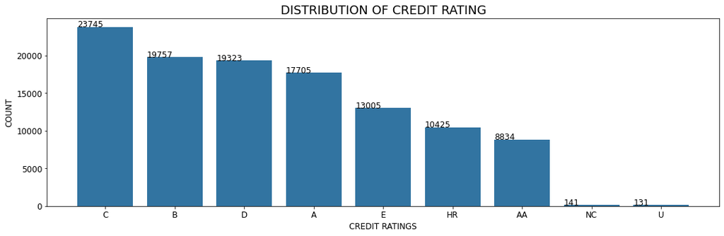

## Duration of Loans

When plotted on a pie chart, we se that most people collect medium term loans. it is also obvious that not a lot of people are interested in short term loans. this could be as a result of the accrued interest rate or it may not be enough time to pay back.

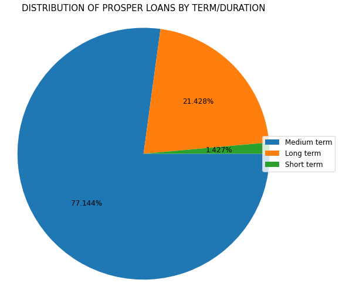

## Distribution of Loan by State

we see that most people that borrow money from Prosper loans live in Carlifonia, followed closely by Texas and then florida. this is understandable because carlifonia has the highest population in the united states, followed by Texas and then Florida. North Dakota has the smallest population in that list so again, it is understandable that the least number of borrowers live there.

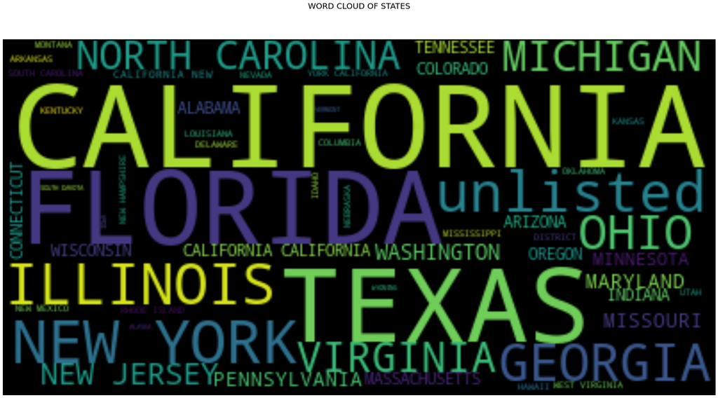

## Relationship between Occupation and Estimated return

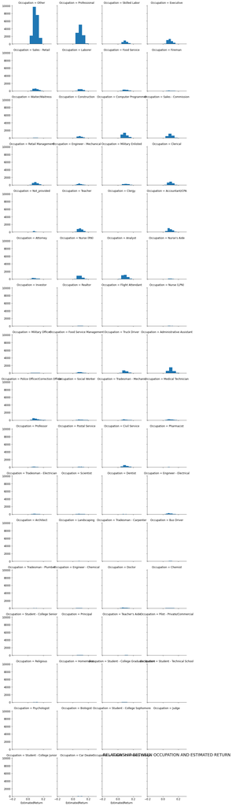

## Borrower APR and Borrower Rate

from our plot, we can see a positive correlation. THis is expected as borrower APR (Annual Percentage rate) is simply total interest rate accrued over a year on a loan. prosper loans may consider giving out more medium term and long term loans as tehy will generate more APR for them.

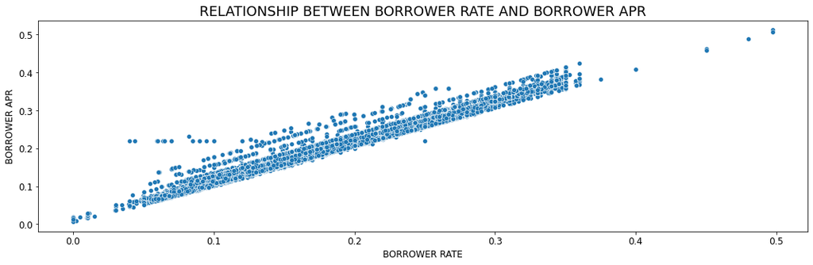